# Exercise 7_1: Data Integration

Advanced Geospatial Data Processing for Social Scientists

Author

Dennis Abel & Stefan Jünger

**Note🏡 Take-home exercise**

This exercise is designed for **after the course** — work on it at your own pace. It brings together everything you’ve learned across all sessions.

In this session, we walked through a full research workflow — from accessing Earth observation data to linking it with survey data. Now it’s your turn! Choose one of two paths:

- **Path A** is open-ended: formulate your own spatial research question and tell a “spatial story” using the course data.
- **Path B** provides a structured step-by-step exercise if you prefer clear guidance.

Both paths practice the core skill of this session: **combining multi-layer geospatial data with tabular data through spatial aggregation and joins.**

## Path A: Spatial Story (open-ended)

**Note🏋️ Your task**

**Tell a spatial story using at least two data sources from this course.**

Formulate a research question and answer it with data. Your analysis must:

1. Use at least one **multi-layer dataset** (a `.nc` Census cube, a raster stack, or a time series)
2. Include a **linkage** between data sources (spatial join, raster extraction, or tabular join)
3. Produce at least one **visualization** of the result

Prepare 2–3 sentences interpreting what you found — and whether you trust the result.

**Caution💡 Inspiration**

Here are some questions you could explore (or invent your own!):

- **Age structure × nighttime lights**: Does the age distribution (from `age_short.nc`) differ between bright and dark areas? Extract nighttime lights and age groups per district, compare.
- **Housing × population change**: Is there a relationship between vacancy rates (`vacancies.tif`) and population trends from the WorldPop time series (2017–2020)?
- **Citizenship × survey context**: Extract citizenship composition (`citizenship.nc`) around the synthetic survey coordinates. Does the neighborhood composition differ by respondents’ citizenship status?
- **Heating × rent**: Do districts with more renewable heating (`building_heat_src.nc`) have higher or lower rents (`rent_avg.tif`)?
- **Your own data**: If you brought your own dataset, this is the time to try integrating it with the Census or WorldPop data!

Remember: Layer names in `.nc` files can be cryptic — use `z22::z22_categories()` or the [Census 2022 database](https://ergebnisse.zensus2022.de/datenbank/online/themes) to decode them.

## Path B: Neighborhood profiles from Census cubes (structured)

In this exercise, you’ll build **neighborhood context profiles** from Census data cubes and link them to the synthetic survey respondents. This mirrors the session workflow — but at a finer spatial scale and with multi-layer data.

### Exercises

**Note🏋️ Exercise 1 — Explore a Census data cube**

Load a `.nc` file from `./data/z22/` — for example, `age_short.nc`. Inspect it:

- How many layers does it have?
- What do the layer names mean? Decode them using `z22::z22_categories("age_short")` or the [Census 2022 database](https://ergebnisse.zensus2022.de/datenbank/online/themes).
- Plot the individual layers side by side. What spatial patterns do you see?

**Caution💡 Tip**

`terra::rast()` handles `.nc` files just like `.tif` — but returns multiple layers. Use `terra::nlyr()` to count them, `names()` to see their names, and `terra::plot()` to visualize all layers at once.

**Note🏋️ Exercise 2 — Extract neighborhood context for survey respondents**

Load the synthetic survey coordinates (`synthetic_survey_geocoordinates.rds`). Extract the values of **all layers** of your Census cube at the respondent locations.

Do this twice:

1. **Point extraction** — direct 1:1 extraction at each coordinate
2. **Buffer extraction** — using a 5 km buffer around each point, averaging across cells

Compare the results: How much do the two approaches differ? Why might you prefer one over the other in practice?

**Caution💡 Tip**

- Watch out for CRS mismatches! Check `sf::st_crs()` and `terra::crs()` before extracting.
- For the buffer approach, use `sf::st_buffer(points, 5000)` (assuming meters) and pass it to `terra::extract(..., fun = mean, na.rm = TRUE)`.
- `terra::extract()` works on multi-layer rasters — it returns one column per layer automatically.

**Note🏋️ Exercise 3 — Link and compare groups**

The synthetic survey coordinates contain an attribute on citizenship status. Use it to compare the **neighborhood profiles** between the two groups:

- Compute the mean of each Census cube layer per group (citizenship status × age bracket)
- Visualize the difference — for example, as a grouped barplot of age shares by citizenship status
- Discuss: Does the spatial context differ between groups? And: since the data are synthetic, can we interpret this as a “real” finding — or is it an artifact?

**Caution💡 Tip**

- After `terra::extract()`, bind the results to the citizenship column — not the full points dataset! The points have other columns with different types that will cause problems during pivoting. Use e.g. `dplyr::tibble(citizenship = points$citizenship) |> dplyr::bind_cols(extracted_values)`.
- Use `tidyr::pivot_longer()` to reshape the wide extraction results into a long format suitable for `ggplot2`.
- For the barplot, `ggplot2::geom_col(position = "dodge")` with `facet_wrap()` by age group works well.
- The critical reflection is part of the exercise — synthetic data are designed to have spatial structure, so patterns you find are intentional but not empirically “real”.

### Solutions

**Tip✅ Solution 1**

```r
library(terra)
# Load the Census data cube
age_cube <- terra::rast("./data/z22/age_short.nc")

# How many layers?
terra::nlyr(age_cube)
```

```
[1] 5
```

```r
# What are they called?
names(age_cube)
```

```
[1] "age_short_Z1=1" "age_short_Z1=2" "age_short_Z1=3" "age_short_Z1=4"
[5] "age_short_Z1=5"
```

```r
# Decode the layer names — what does each layer represent?
# Option 1: z22 package (if installed)
# z22::z22_categories("age_short")
# Option 2: check https://ergebnisse.zensus2022.de/datenbank/online/themes

# Inspect the metadata
print(age_cube)
```

```
class       : SpatRaster
size        : 859, 641, 5  (nrow, ncol, nlyr)
resolution  : 1000, 1000  (x, y)
extent      : 4031000, 4672000, 2689000, 3548000  (xmin, xmax, ymin, ymax)
coord. ref. : ETRS89-extended / LAEA Europe (EPSG:3035)
source      : age_short.nc
names       : age_short_Z1=1, age_short_Z1=2, age_short_Z1=3, age_short_Z1=4, age_short_Z1=5
depth       : 1 to 5 (Z1: 5 steps)
```

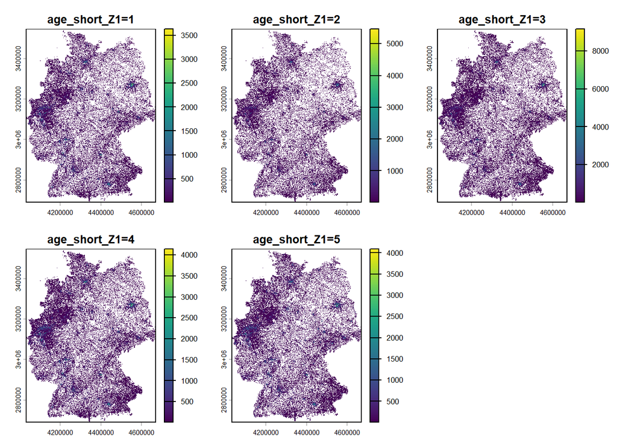

```r
# Plot all layers — each shows a different age group's share
terra::plot(age_cube)
```

**Tip✅ Solution 2**

```r
library(sf)
# Load survey coordinates
points <- readRDS("./data/survey/synthetic_survey_geocoordinates.rds")

# Check CRS of both datasets
sf::st_crs(points)$epsg
```

```
[1] 3035
```

```r
terra::crs(age_cube, describe = TRUE)$code
```

```
[1] "3035"
```

```r
# Reproject points to match the raster CRS
points <- sf::st_transform(points, terra::crs(age_cube))

# --- Point extraction (1:1) ---
extracted_point <- terra::extract(age_cube, points, ID = FALSE)
head(extracted_point)
```

```
  age_short_Z1=1 age_short_Z1=2 age_short_Z1=3 age_short_Z1=4 age_short_Z1=5
1            329            308            416            414            377
2           2265           1525           2382           1752           1833
3            498            412            762            775            760
4            639            634           1268            985           1353
5             55             26             68             97             55
6            414            263            556            558            525
```

```r
# --- Buffer extraction (5 km neighborhood) ---
buffers <- sf::st_buffer(points, 5000)
extracted_buffer <- terra::extract(
  age_cube, buffers, fun = mean, na.rm = TRUE, ID = FALSE
)
head(extracted_buffer)
```

```
  age_short_Z1=1 age_short_Z1=2 age_short_Z1=3 age_short_Z1=4 age_short_Z1=5
1       83.63636        65.2000      105.58333       93.71154       96.80769
2      665.19118       482.8235      843.22059      706.16176      637.54412
3      233.83582       170.9394      347.68182      329.92754      315.36232
4      323.69492       226.2373      504.93333      409.25806      437.23729
5       43.45000        20.8125       61.14286       64.47619       73.33333
6      158.11594       107.0286      213.75714      208.41429      203.77143
```

```r
# --- Compare the two approaches ---
# The buffer values should be smoother (less extreme)
# because they average over multiple grid cells
summary(extracted_point)
```

```
 age_short_Z1=1   age_short_Z1=2    age_short_Z1=3   age_short_Z1=4
 Min.   :   3.0   Min.   :   3.00   Min.   :   4.0   Min.   :   3.0
 1st Qu.:  91.0   1st Qu.:  56.75   1st Qu.: 117.5   1st Qu.: 132.5
 Median : 243.0   Median : 170.00   Median : 354.0   Median : 350.0
 Mean   : 432.9   Mean   : 414.26   Mean   : 730.8   Mean   : 552.5
 3rd Qu.: 583.0   3rd Qu.: 458.00   3rd Qu.: 877.5   3rd Qu.: 791.0
 Max.   :4180.0   Max.   :5467.00   Max.   :9888.0   Max.   :4412.0
 NAs    :3        NAs    :8         NAs    :1        NAs    :1
 age_short_Z1=5
 Min.   :   3.0
 1st Qu.: 123.0
 Median : 334.0
 Mean   : 560.1
 3rd Qu.: 826.0
 Max.   :2594.0
 NAs    :3
```

```r
summary(extracted_buffer)
```

```
 age_short_Z1=1    age_short_Z1=2     age_short_Z1=3    age_short_Z1=4
 Min.   :  10.55   Min.   :   4.273   Min.   :  14.00   Min.   :  13.72
 1st Qu.:  53.03   1st Qu.:  36.545   1st Qu.:  70.57   1st Qu.:  73.43
 Median : 106.58   Median :  77.823   Median : 152.75   Median : 137.14
 Mean   : 215.57   Mean   : 196.115   Mean   : 354.78   Mean   : 264.24
 3rd Qu.: 274.14   3rd Qu.: 216.964   3rd Qu.: 399.53   3rd Qu.: 341.05
 Max.   :1663.56   Max.   :1699.357   Max.   :3419.66   Max.   :1755.30
 age_short_Z1=5
 Min.   :  11.89
 1st Qu.:  74.76
 Median : 141.25
 Mean   : 260.13
 3rd Qu.: 338.82
 Max.   :1490.93
```

**Tip✅ Solution 3**

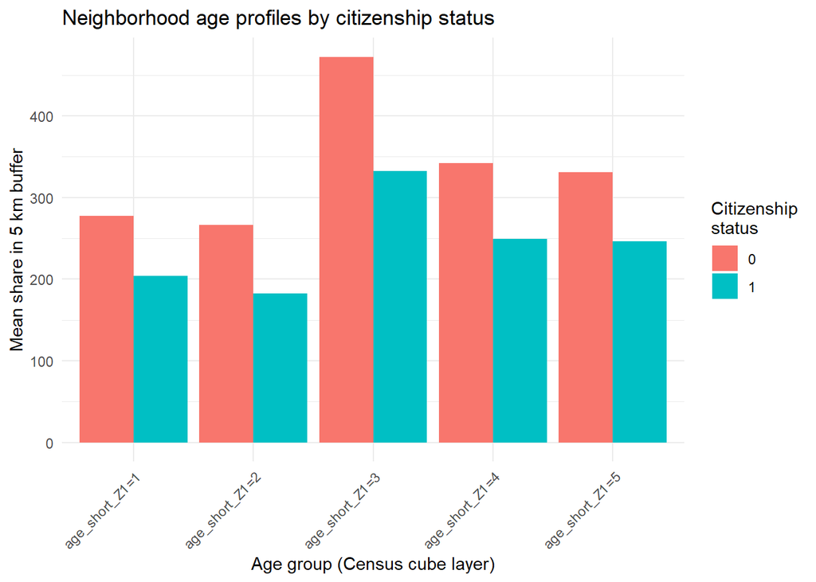

```r
library(dplyr)
library(tidyr)
library(ggplot2)

# Combine extraction results with the citizenship attribute
points_enriched <-
  dplyr::tibble(citizenship = points$citizenship) |>  # keep only grouping variable
  dplyr::bind_cols(extracted_buffer) |>               # add extracted values
  tidyr::pivot_longer(                                # reshape to long format
    cols = -citizenship,                              # pivot only the age layers
    names_to = "age_group",
    values_to = "share"
  )

# Compute group means
group_profiles <- points_enriched |>
  dplyr::group_by(citizenship, age_group) |>
  dplyr::summarize(mean_share = mean(share, na.rm = TRUE), .groups = "drop")

# Visualize
ggplot(group_profiles, aes(x = age_group, y = mean_share, fill = factor(citizenship))) +
  geom_col(position = "dodge") +
  labs(
    title = "Neighborhood age profiles by citizenship status",
    x = "Age group (Census cube layer)",
    y = "Mean share in 5 km buffer",
    fill = "Citizenship\nstatus"
  ) +
  theme_minimal() +
  theme(axis.text.x = element_text(angle = 45, hjust = 1))
```

The synthetic data were designed to have spatial structure, so any pattern we find is “built in” by the data generation process — not evidence for a real-world association. In a real analysis, this is exactly where you’d discuss ecological fallacy, selection effects, and whether the spatial scale of your buffer matches your theoretical mechanism.